### Install dependencies

```python
!pip install pandas
!pip install numpy
!pip install matplotlib
!pip install scikit-learn
!pip install openpyxl
!pip install seaborn
!pip install tabulate
```

# FPSO Equipment Failure Analysis

## Challenge:

Analysis focused on predicting equipment failures in an FPSO (Floating Production, Storage, and Offloading) vessel. Where it's need to:

1. Calculate how many times the equipment has failed.
2. Categorize equipment failures by setup configurations (Preset 1 and Preset 2)
3. Categorize equipment failures by their nature/root cause according to parameter readings (temperature, pressure, and others)
4. Create a model (or models) using the technique you think is most appropriate and measure its performance.
5. Analyze variable importance

## Dataset Description

- **Cycle**: Sequential identifier of measurement cycles
- **Preset_1 & Preset_2**: Variables that control a specific operating point of the machine.
- **Temperature**: Temperature recorded in the equipment.
- **Vibrations (X, Y & Z)**: Vibrations along the machine's axes.
- **Frequency**: Operating frequency of the machine.
- **Fail**: Variable indicating whether the machine is in a failure state at the given timestamp.

```python
import pandas as pd
import numpy as np
import matplotlib.pyplot as plt
import seaborn as sns
from datetime import datetime
import warnings
warnings.filterwarnings('ignore')
```

#### Load dataset

```python
df = pd.read_excel('data/Test O_G_Equipment_Data.xlsx')
print("Dataset loaded successfully")
print("showing first 5 rows of the dataset")
df.head()
```

```
Dataset loaded successfully
showing first 5 rows of the dataset
```

|  | Cycle | Preset_1 | Preset_2 | Temperature | Pressure | VibrationX | VibrationY | VibrationZ | Frequency | Fail |
| --- | --- | --- | --- | --- | --- | --- | --- | --- | --- | --- |
| 0 | 1 | 3 | 6 | 44.235186 | 47.657254 | 46.441769 | 64.820327 | 66.454520 | 44.483250 | False |
| 1 | 2 | 2 | 4 | 60.807234 | 63.172076 | 62.005951 | 80.714431 | 81.246405 | 60.228715 | False |
| 2 | 3 | 2 | 1 | 79.027536 | 83.032190 | 82.642110 | 98.254386 | 98.785196 | 80.993479 | False |
| 3 | 4 | 2 | 3 | 79.716242 | 100.508634 | 122.362321 | 121.363429 | 118.652538 | 80.315567 | False |
| 4 | 5 | 2 | 5 | 39.989054 | 51.764833 | 42.514302 | 61.037910 | 50.716469 | 64.245166 | False |

```python
print("checking for missing values")
if df.isna().sum().any():
    print("\t missing values found")
else:
    print("\t No missing values found")

print("checking for duplicate values")
if df.duplicated().sum() > 0:
    print("\t duplicate values found")
else:
    print("\t No duplicate values found")
```

```
checking for missing values
	 No missing values found
checking for duplicate values
	 No duplicate values found
```

```python
print(f"Number of cycles: {len(df)}")
print(f"Number of variables: {len(df.columns)}")
print(f"Time period: {df['Cycle'].min()} to {df['Cycle'].max()} cycles")
```

```
Number of cycles: 800
Number of variables: 10
Time period: 1 to 800 cycles
```

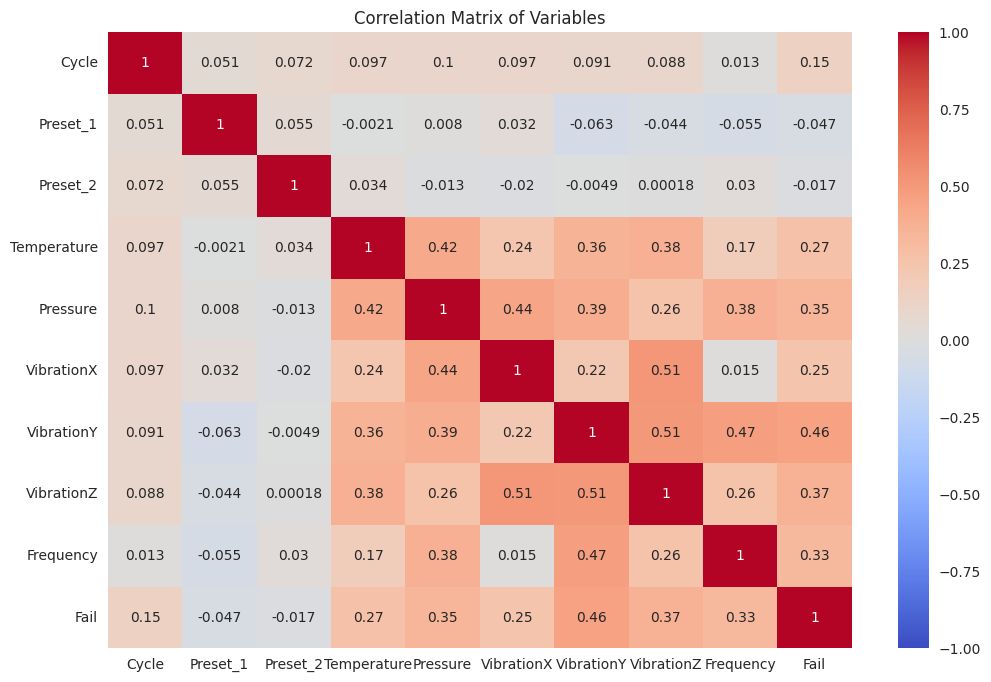

```python
# correlation matrix between all variables with the Fail variable
corr_matrix = df.corr()
plt.figure(figsize=(12, 8))
sns.heatmap(corr_matrix, annot=True, cmap='coolwarm', vmin=-1, vmax=1, center=0)
plt.title('Correlation Matrix of Variables')
plt.show()
```

## 1. Calculate how many times the equipment has failed.

```python
# Basic failure statistics
df_failures = df[df['Fail'] == True]
total_failures = len(df_failures)
total_cycles = len(df)
failure_rate = (total_failures / total_cycles) * 100

print(f"Total number of failure cycles: {total_failures}")
print(f"Total measurement cycles: {total_cycles}")
print(f"Failure rate: {failure_rate:.2f}%")
```

```
Total number of failure cycles: 66
Total measurement cycles: 800
Failure rate: 8.25%
```

#### Identify failure episodes (consecutive failure cycles)

```python
# sort df by Cycle, just to be sure that the cycles are in order
df = df.sort_values(by='Cycle')
```

```python
df['failure_episode'] = 0
episode_id = 0
is_in_failure_episode = False

for i, row in df.iterrows():
    is_cycle_failure = row['Fail']
    if is_cycle_failure:
        if not is_in_failure_episode:
            # Start of new failure episode
            episode_id += 1
            is_in_failure_episode = True
            df.at[i, 'failure_episode'] = episode_id
        else:
            # Continuation of current failure episode
            df.at[i, 'failure_episode'] = episode_id
    else:
        is_in_failure_episode = False
```

```python
df_failures_episodes = df[df['failure_episode'] > 0]
n_unique_failure_episodes = df_failures_episodes['failure_episode'].nunique()
print(f"Number of unique failure episodes: {n_unique_failure_episodes}")

# Calculate failure rate for each failure episode
failures_episodes_grouped = df_failures_episodes.groupby('failure_episode').size()
print(f"\nFailure episode duration statistics:")
print(f"Mean duration: {failures_episodes_grouped.mean():.2f} cycles")
print(f"Median duration: {failures_episodes_grouped.median():.2f} cycles")
print(f"Min duration: {failures_episodes_grouped.min()} cycles")
print(f"Max duration: {failures_episodes_grouped.max()} cycles")
print(f"Standard deviation: {failures_episodes_grouped.std():.2f} cycles")
```

```
Number of unique failure episodes: 10

Failure episode duration statistics:
Mean duration: 6.60 cycles
Median duration: 4.00 cycles
Min duration: 1 cycles
Max duration: 18 cycles
Standard deviation: 5.64 cycles
```

#### Failure distribution over cycles

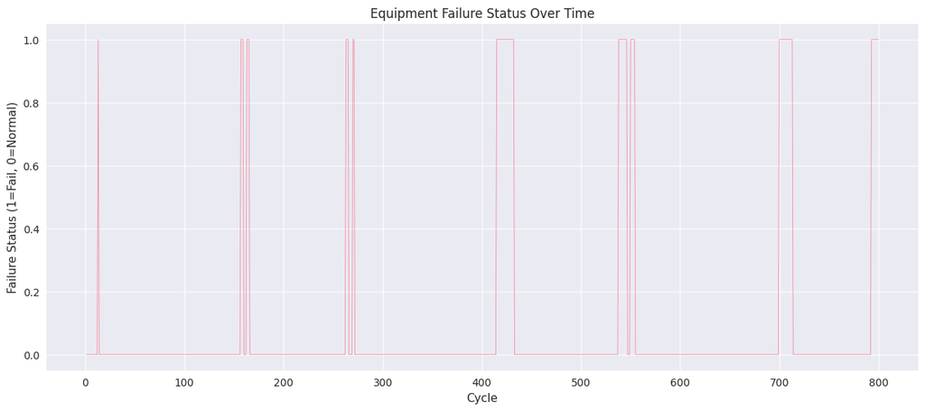

```python
plt.figure(figsize=(15, 6))
plt.plot(df['Cycle'], df['Fail'], alpha=0.8, linewidth=.6)
plt.title('Equipment Failure Status Over Time')
plt.xlabel('Cycle')
plt.ylabel('Failure Status (1=Fail, 0=Normal)')
plt.grid(True, alpha=0.8)
```

The equipment has failed 10 times throughout its operation. These failures occurred across 66 individual cycles, representing 8.25% of the total operational time. Each failure episode lasted an average of 6.6 cycles, with episodes ranging from 1 to 18 cycles in duration.

=========================================================

## 2. Categorize equipment failures by setup configurations (Preset 1 and Preset 2)

##### * **Preset_1 & Preset_2**: Variables that control a specific operating point of the machine.

```python
# describe Preset_1 and Preset_2
print(df[['Preset_1', 'Preset_2']].describe())
print("-"*100)
print('Preset_1 unique values:')
print(sorted(df['Preset_1'].unique()))
print("-"*100)
print('Preset_2 unique values:')
print(sorted(df['Preset_2'].unique()))
print("-"*100)
```

```
         Preset_1    Preset_2
count  800.000000  800.000000
mean     1.988750    4.551250
std      0.805875    2.293239
min      1.000000    1.000000
25%      1.000000    3.000000
50%      2.000000    5.000000
75%      3.000000    7.000000
max      3.000000    8.000000
----------------------------------------------------------------------------------------------------
Preset_1 unique values:
[np.int64(1), np.int64(2), np.int64(3)]
----------------------------------------------------------------------------------------------------
Preset_2 unique values:
[np.int64(1), np.int64(2), np.int64(3), np.int64(4), np.int64(5), np.int64(6), np.int64(7), np.int64(8)]
----------------------------------------------------------------------------------------------------
```

Next, let's analyze the Presets individually

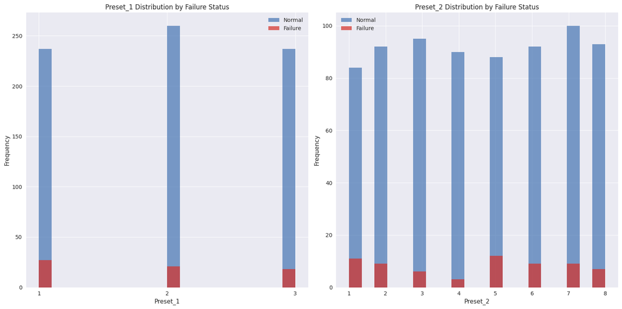

```python
cmap = plt.get_cmap("RdYlBu_r")
color_fail = cmap(0.9)
color_no_fail = cmap(0.1)

plt.figure(figsize=(16, 8))
plt.subplot(1, 2, 1)
df[df['Fail'] == 0]['Preset_1'].hist(alpha=0.7, label='Normal', bins=20, color=color_no_fail)
df[df['Fail'] == 1]['Preset_1'].hist(alpha=0.7, label='Failure', bins=20, color=color_fail)
plt.xticks(df['Preset_1'].unique())
plt.xlabel('Preset_1')
plt.ylabel('Frequency')
plt.title('Preset_1 Distribution by Failure Status')
plt.legend()
plt.grid(True, alpha=0.8)


plt.subplot(1, 2, 2)
df[df['Fail'] == 0]['Preset_2'].hist(alpha=0.7, label='Normal', bins=20, color=color_no_fail)
df[df['Fail'] == 1]['Preset_2'].hist(alpha=0.7, label='Failure', bins=20, color=color_fail)

plt.xticks(df['Preset_2'].unique())
plt.xlabel('Preset_2')
plt.ylabel('Frequency')
plt.title('Preset_2 Distribution by Failure Status')
plt.legend()
plt.grid(True, alpha=0.8)
plt.tight_layout()
plt.show()
```

From the graphs above, we can note that when Preset_1=3, we had fewer failure cases. For Preset_2, when it is 4, we had fewer failure cases.

When Preset_1=1 and Preset_2=5, analyzing them individually, we see that these were the configurations where more failure cases occurred.

```python
# combinations of Preset_1 and Preset_2 with their failure rates
# for Fail column, we can consider True as 1 and False as 0, so we can compute mean, count, sum, etc.
df_preset_combinations = df.groupby(['Preset_1', 'Preset_2']).agg({
    'Fail': ['sum', 'mean'],
    'Cycle': 'count'
}).round(4)

df_preset_combinations.columns = ['failure_cycles', 'failure_rate', 'total_cycles']

df_preset_combinations = df_preset_combinations[df_preset_combinations['total_cycles'] > 0] # considering only the combinations that have more than 0 cycles

df_preset_combinations = df_preset_combinations.sort_values('failure_rate', ascending=False) # sort by failure rate descending

n_total_combinations = len(df_preset_combinations)
print(f"Number of unique combinations of Preset_1 and Preset_2: {n_total_combinations}")
```

```
Number of unique combinations of Preset_1 and Preset_2: 24
```

```python
df_preset_combinations.head(n_total_combinations)
```

| Preset_1 | Preset_2 | failure_cycles | failure_rate | total_cycles |
| --- | --- | --- | --- | --- |
| 1 | 5 | 5 | 0.1613 | 31 |
| 3 | 5 | 4 | 0.1379 | 29 |
| 2 | 1 | 4 | 0.1333 | 30 |
| 1 | 2 | 5 | 0.1316 | 38 |
|  | 1 | 4 | 0.1176 | 34 |
| 2 | 8 | 4 | 0.1081 | 37 |
| 1 | 7 | 4 | 0.1053 | 38 |
| 3 | 6 | 3 | 0.1000 | 30 |
|  | 1 | 3 | 0.0968 | 31 |
| 1 | 4 | 2 | 0.0909 | 22 |
|  | 6 | 3 | 0.0882 | 34 |
| 3 | 7 | 3 | 0.0882 | 34 |
| 1 | 8 | 2 | 0.0833 | 24 |
| 2 | 6 | 3 | 0.0811 | 37 |
|  | 3 | 2 | 0.0769 | 26 |
|  | 5 | 3 | 0.0750 | 40 |
| 3 | 2 | 2 | 0.0690 | 29 |
|  | 3 | 2 | 0.0625 | 32 |
| 2 | 2 | 2 | 0.0588 | 34 |
|  | 7 | 2 | 0.0541 | 37 |
| 1 | 3 | 2 | 0.0465 | 43 |
| 3 | 8 | 1 | 0.0256 | 39 |
| 2 | 4 | 1 | 0.0250 | 40 |
| 3 | 4 | 0 | 0.0000 | 31 |

From the previous table, we can note that only when Preset_1=3 and Preset_2=4, we have no failures, even running for 31 cycles.

But other combinations are interesting too, like (Preset_1=2, Preset_2=4) and (Preset_1=3, Preset_2=8), where we have only 1 failure, even running for 40 and 39 cycles, respectively.

On the other hand, the combinations (Preset_1=1, Preset_2=5) and (Preset_1=1, Preset_2=2) were the ones that had more failure cases (5).

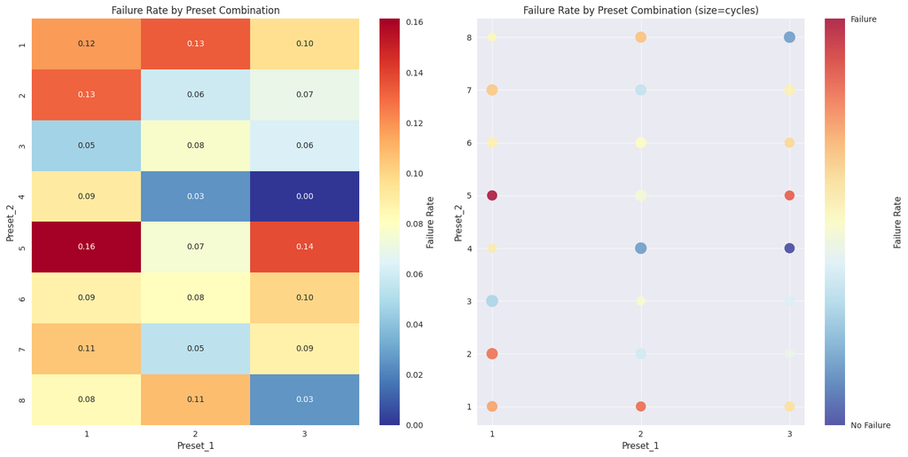

```python
plt.figure(figsize=(16, 8))
plt.subplot(1, 2, 1)
heatmap_data = df_preset_combinations.reset_index().pivot(
    index='Preset_2', columns='Preset_1', values='failure_rate'
)

sns.heatmap(
    heatmap_data, annot=True, fmt=".2f", cmap="RdYlBu_r",
    cbar_kws={'label': 'Failure Rate'}
)

plt.title("Failure Rate by Preset Combination")
plt.xlabel("Preset_1")
plt.ylabel("Preset_2")
#plt.show()

plt.subplot(1, 2, 2)
scatter = plt.scatter(
    df_preset_combinations.index.get_level_values('Preset_1'),
    df_preset_combinations.index.get_level_values('Preset_2'),
    c=df_preset_combinations['failure_rate'],
    cmap='RdYlBu_r', s=df_preset_combinations['total_cycles']*5, alpha=0.8
)

cbar = plt.colorbar(scatter)
cbar.set_label("Failure Rate")

cbar.set_ticks([df_preset_combinations['failure_rate'].min(), df_preset_combinations['failure_rate'].max()])
cbar.set_ticklabels(['No Failure', 'Failure'])

plt.xticks(df['Preset_1'].unique())
plt.yticks(df['Preset_2'].unique())
plt.xlabel("Preset_1")
plt.ylabel("Preset_2")
plt.title("Failure Rate by Preset Combination (size=cycles)")
plt.grid(True, alpha=0.6)
plt.tight_layout()
plt.show()
```

The graphs above help us understand which combinations have higher and lower failure rates. In the left graph, values close to zero (or more blue) indicate combinations with lower failure rates. For example, when Preset_1=3 and Preset_2=4, we have the value 0.0 with the strongest blue color, indicating that this combination has 0% failure rate, which is excellent. However, when Preset_1=1 and Preset_2=5, we have 16% failure rate, meaning with this combination we had 16% failure rate.

The idea of the right graph is the same - the more blue, the better the Preset combination, given that fewer failures occurred for these combinations. While the more red, the more failures occurred for the combinations.

Below, let's retrieve the 3 combinations of preset_1 and preset_2 with lowest and highest failure rates.

```python
df_preset_combinations.sort_values('failure_rate', ascending=False, inplace=True)

print("Top 3 preset combinations with lowest failure rates:")
for idx, row in df_preset_combinations.tail(3).sort_values('failure_rate').iterrows():
    print(f"Preset_1={idx[0]}, Preset_2={idx[1]}: {(row['failure_rate']*100):.2f}% failure rate ({row['failure_cycles']}/{row['total_cycles']} cycles)")

print("-"*100)
print("Top 3 preset combinations with highest failure rates:")
for idx, row in df_preset_combinations.head(3).iterrows():
    print(f"Preset_1={idx[0]}, Preset_2={idx[1]}: {(row['failure_rate']*100):.2f}% failure rate ({row['failure_cycles']}/{row['total_cycles']} cycles)")
```

```
Top 3 preset combinations with lowest failure rates:
Preset_1=3, Preset_2=4: 0.00% failure rate (0.0/31.0 cycles)
Preset_1=2, Preset_2=4: 2.50% failure rate (1.0/40.0 cycles)
Preset_1=3, Preset_2=8: 2.56% failure rate (1.0/39.0 cycles)
----------------------------------------------------------------------------------------------------
Top 3 preset combinations with highest failure rates:
Preset_1=1, Preset_2=5: 16.13% failure rate (5.0/31.0 cycles)
Preset_1=3, Preset_2=5: 13.79% failure rate (4.0/29.0 cycles)
Preset_1=2, Preset_2=1: 13.33% failure rate (4.0/30.0 cycles)
```

=========================================================

## 3. Categorize equipment failures by their nature/root cause according to parameter readings (temperature, pressure, and others)

```python
def get_thresholds(df, sensor_vars, thresholds=None):
    """
    Get (or include missing) the thresholds for the sensor variables
    df: pd.DataFrame, the dataframe containing the sensor variables
    sensor_vars: list, the list of sensor variables
    thresholds: dict, the thresholds for the sensor variables
    """
    if thresholds is None:
        thresholds = {}
    for var in sensor_vars:
        if var in df.columns:
            if f'{var}_high' not in thresholds:
                thresholds[f'{var}_high'] = df[var].quantile(0.95)
            if f'{var}_low' not in thresholds:
                thresholds[f'{var}_low'] = df[var].quantile(0.05)
    return thresholds

def check_root_cause(row, possible_root_cause, thresholds, compare_high, compare_low):

    """
    Check if the possible root cause is a root cause of the failure
    possible_root_cause: str, the name of the possible root cause
    thresholds: dict, the thresholds for the possible root cause
    compare_high: bool, whether to compare the possible root cause to the high threshold
    compare_low: bool, whether to compare the possible root cause to the low threshold
    """
    categories = []
    if possible_root_cause not in row:
        print(f"Variable {possible_root_cause} not found in row")
        return categories
    if compare_high:
        if row[possible_root_cause] > thresholds[f'{possible_root_cause}_high']:
            categories.append(f'High_{possible_root_cause}')
    if compare_low:
        if row[possible_root_cause] < thresholds[f'{possible_root_cause}_low']:
            categories.append(f'Low_{possible_root_cause}')
    return categories

def categorize_failures_by_sensors(df,
                                    sensor_vars=[
                                                    'Temperature',
                                                    'Pressure',
                                                    'VibrationX',
                                                    'VibrationY',
                                                    'VibrationZ',
                                                    'Frequency'],
                                    thresholds=None
                                    ):
    """
    Categorize failures based on sensor readings to identify potential root causes
    df: pd.DataFrame, the dataframe containing the sensor variables
    sensor_vars: list, the list of sensor variables
    thresholds: dict, the thresholds for the sensor variables
    """
    df_failure_data = df[df['Fail'] == True].copy()

    if len(df_failure_data) == 0:
        return pd.DataFrame()

    df_non_failure_data = df[df['Fail'] == False]
    # get thresholds for normal operation, i.e. when Fail=False
    thresholds = get_thresholds(df_non_failure_data, sensor_vars, thresholds)


    failure_categories = []
    for idx, row in df_failure_data.iterrows():
        categories = []
        categories.extend(check_root_cause(row, possible_root_cause='Temperature', thresholds=thresholds, compare_high=True, compare_low=True))
        categories.extend(check_root_cause(row, possible_root_cause='VibrationX', thresholds=thresholds, compare_high=True, compare_low=False))
        categories.extend(check_root_cause(row, possible_root_cause='VibrationY', thresholds=thresholds, compare_high=True, compare_low=False))
        categories.extend(check_root_cause(row, possible_root_cause='VibrationZ', thresholds=thresholds, compare_high=True, compare_low=False))
        categories.extend(check_root_cause(row, possible_root_cause='Frequency', thresholds=thresholds, compare_high=True, compare_low=True))

        if len(categories) == 0: # no categories found, so it's an unknown pattern
            categories.append('unknown')

        failure_categories.append(' + '.join(categories))

    df_failure_data['failure_category'] = failure_categories
    return df_failure_data
```

Let's consider the data without failures as a baseline, in this case we'll use the extremes of each data as thresholds. For example, in the context of Temperature, assuming that the data that did not have Failures has the following temperatures: [10, 15, 10, 20, 22, 11, 10]. Thus, we'll consider the 5% and 95% quantiles as lower and upper thresholds, respectively. Thus, temperatures below the lower threshold or above the upper threshold can be considered possible causes of failures.

We'll perform the analysis considering: Temperature, VibrationX, VibrationY, VibrationZ and Frequency. However, only for Temperature and Frequency we'll consider both lower and upper limits, for Vibration cases, we'll consider only the upper limit. This is because we're assuming that, in the case of Vibrations, we can only have problems when it's in excess.

```python
# Example of how to calculate the thresholds
l = [10, 10, 10, 11, 15, 20, 22]
quantile_05 = np.percentile(l, 5)
quantile_95 = np.percentile(l, 95)
print(f"Threshold inferior: {quantile_05}")
print(f"Threshold superior: {quantile_95}")
```

```
Threshold inferior: 10.0
Threshold superior: 21.4
```

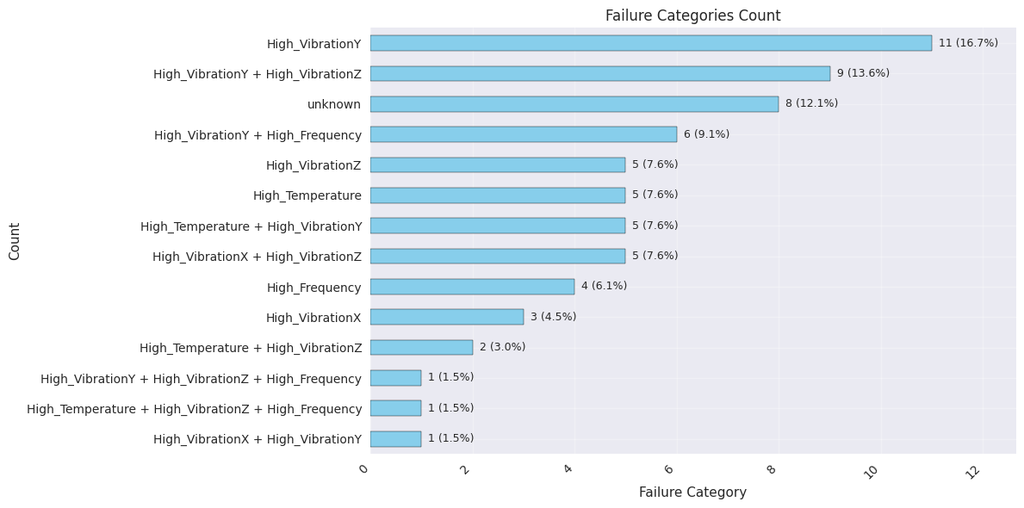

```python
# Categorize failures
sensor_vars = ['Temperature', 'VibrationX', 'VibrationY', 'VibrationZ', 'Frequency']
categorized_failures = categorize_failures_by_sensors(df, sensor_vars=sensor_vars)

if len(categorized_failures) > 0:
    category_counts = categorized_failures['failure_category'].value_counts().sort_values(ascending=True)

    # Visualize failure categories
    plt.figure(figsize=(12, 6))

    # horizontal Bar chart of failure categories with percentage in the top of the bar
    plt.subplot(1, 1, 1)
    category_counts.plot(kind='barh', color='skyblue', edgecolor='black')

    for i, (category, count) in enumerate(category_counts.items()):
        plt.text(count, i, f'  {count} ({count/len(categorized_failures)*100:.1f}%)',
                 ha='left', va='center', fontsize=9)

    plt.title('Failure Categories Count')
    plt.xlabel('Failure Category')
    plt.ylabel('Count')
    plt.xlim(0, category_counts.max()*1.15)
    plt.xticks(rotation=45, ha='right')
    plt.grid(True, alpha=0.3)


    plt.tight_layout()
    plt.show()
```

Considering the graph above, it can be seen that High Vibrations in Y (alone) may be causing more than 16% of failures. However, it can be seen that High vibrations in Y appear in combination with other probable causes, such as: High Vibrations in Y and Z, High Vibrations in Y and High frequency, High vibrations in Y and High temperature, among other occurrences.

It's also possible to notice that, according to the proposed approach, 12% of failures cannot be explained. As well as it can be seen that there are no problems related to the lower limit, i.e., low temperature problems, for example.

Thus, let's analyze the possible causes individually, i.e., if High_Temperature combined with High_VibrationY is a cause, we'll consider as causes High_Temperature and High_VibrationY.

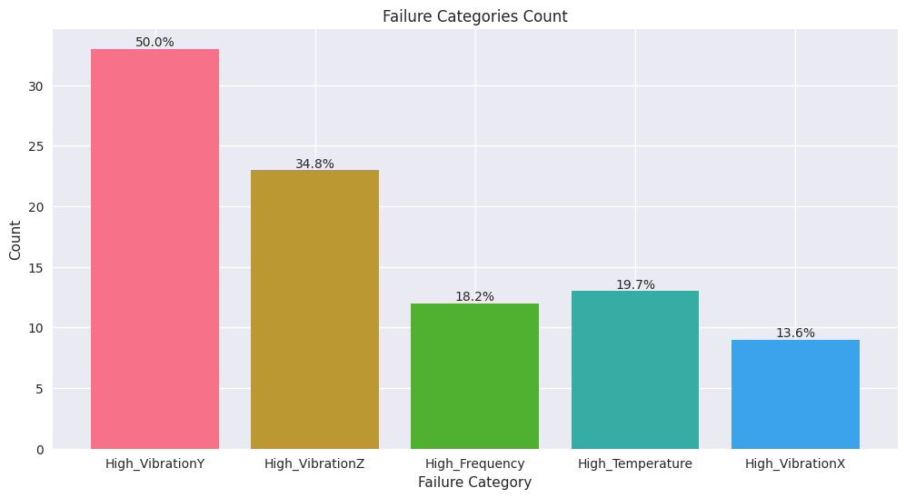

```python
d_individual_failure_categories = {}
for index, row in categorized_failures.iterrows():
    for sensor in sensor_vars:
        if 'High_' + sensor in row['failure_category']:
            if 'High_' + sensor not in d_individual_failure_categories:
                d_individual_failure_categories['High_' + sensor] = 0
            d_individual_failure_categories['High_' + sensor] += 1

plt.figure(figsize=(12, 6))


for category, count in d_individual_failure_categories.items():
    plt.bar(category, count)
    # add the percentage of the failure category
    plt.text(category, count, f'{count/len(categorized_failures)*100:.1f}%', ha='center', va='bottom')
plt.title('Failure Categories Count')
plt.xlabel('Failure Category')
plt.ylabel('Count')
plt.show()
```

=========================================================

## 4. Create a model (or models) using the technique you think is most appropriate and measure its performance.

```python
# Import additional libraries for machine learning
from sklearn.model_selection import cross_val_score
from sklearn.ensemble import RandomForestClassifier, GradientBoostingClassifier
from sklearn.linear_model import LogisticRegression
from sklearn.svm import SVC
from sklearn.metrics import classification_report, confusion_matrix, roc_auc_score, roc_curve
from sklearn.preprocessing import StandardScaler
```

```python
# Create additional time-series features
def create_time_series_features(df, window_sizes=[3, 5, 10]):
    """Create rolling window features for time-series prediction"""
    df_features = df.copy()

    for window in window_sizes:
        for col in ['Temperature', 'VibrationX', 'VibrationY', 'VibrationZ', 'Frequency']:
            if col in df.columns:
                # Rolling statistics
                df_features[f'{col}_mean_{window}'] = df[col].rolling(window=window, min_periods=1).mean() # mean of the last window size values
                df_features[f'{col}_std_{window}'] = df[col].rolling(window=window, min_periods=1).std() # standard deviation of the last window size values
                df_features[f'{col}_max_{window}'] = df[col].rolling(window=window, min_periods=1).max() # max of the last window size values
                df_features[f'{col}_min_{window}'] = df[col].rolling(window=window, min_periods=1).min() # min of the last window size values

                # Trend features
                df_features[f'{col}_trend_{window}'] = df[col].diff(window) # difference between the current and previous value

    return df_features
```

```python
feature_columns = ['Preset_1', 'Preset_2', 'Temperature', 'VibrationX', 'VibrationY', 'VibrationZ', 'Frequency']
x = df[feature_columns].copy()
y = df['Fail'].astype(int)  # Convert boolean to int

print(f"Class distribution: {y.value_counts()}")
print(f"Failure rate: {y.mean():.3f}")
```

```
Class distribution: Fail
0    734
1     66
Name: count, dtype: int64
Failure rate: 0.083
```

It's importante to note that the dataset it's not balanced.

```python
# Create enhanced features
df_features_enhanced = create_time_series_features(df)

# remove the columns that are not features
l_features = [col for col in df_features_enhanced.columns if col not in ['Cycle', 'Fail', 'failure_episode']]
df_features_enhanced = df_features_enhanced[l_features].fillna(0)  # Fill NaN values with 0

print(f"Enhanced features shape: {df_features_enhanced.shape}")
print(f"Number of enhanced features: {len(l_features)}")
```

```
Enhanced features shape: (800, 83)
Number of enhanced features: 83
```

```python
# Split data for training and testing
n_train_data = int(0.8 * len(df))

y_train = y[:n_train_data]
y_test = y[n_train_data:]

x_train_enhanced = df_features_enhanced[:n_train_data]
x_test_enhanced = df_features_enhanced[n_train_data:]

# Scale features for algorithms that require it
# for example, the Logistic Regression and SVM models require scaled features
# So, we'll scale the features using the mean and standard deviation of the training data
scaler = StandardScaler()
X_train_scaled = scaler.fit_transform(x_train_enhanced)
X_test_scaled = scaler.transform(x_test_enhanced)

# Define models to test
# its importante to note that I'm using the class_weight='balanced' to handle the imbalance of the data
models = {
    'Random Forest': RandomForestClassifier(random_state=42, class_weight='balanced'),
    'Gradient Boosting': GradientBoostingClassifier(random_state=42),
    'Logistic Regression': LogisticRegression(random_state=42, class_weight='balanced', max_iter=1000),
    'SVM': SVC(random_state=42, class_weight='balanced', probability=True)
}

# Train and evaluate models
results = {}
trained_models = {}

for name, model in models.items():
    print(f"--- Training {name} ---")

    if name in ['Logistic Regression', 'SVM']:
        # Use scaled features for linear models
        model.fit(X_train_scaled, y_train)
        y_pred = model.predict(X_test_scaled)
        y_pred_proba = model.predict_proba(X_test_scaled)[:, 1]
    else:
        # Use original features for tree-based models
        model.fit(x_train_enhanced, y_train)
        y_pred = model.predict(x_test_enhanced)
        y_pred_proba = model.predict_proba(x_test_enhanced)[:, 1]

    # Calculate metrics
    auc_score = roc_auc_score(y_test, y_pred_proba)

    # Cross-validation score
    if name in ['Logistic Regression', 'SVM']:
        cv_scores = cross_val_score(model, X_train_scaled, y_train, cv=5, scoring='roc_auc')
    else:
        cv_scores = cross_val_score(model, x_train_enhanced, y_train, cv=5, scoring='roc_auc')

    results[name] = {
        'model': model,
        'auc_score': auc_score,
        'cv_mean': cv_scores.mean(),
        'cv_std': cv_scores.std(),
        'y_pred': y_pred,
        'y_pred_proba': y_pred_proba
    }
    trained_models[name] = model

    print(f"AUC Score: {auc_score:.3f}")
    print(f"CV AUC Score: {cv_scores.mean():.3f} (+/- {cv_scores.std() * 2:.3f})")
    print(f"Report:")
    print(classification_report(y_test, y_pred))
```

```
--- Training Random Forest ---
AUC Score: 0.936
CV AUC Score: 0.980 (+/- 0.044)
Report:
              precision    recall  f1-score   support

           0       0.93      0.96      0.95       138
           1       0.71      0.55      0.62        22

    accuracy                           0.91       160
   macro avg       0.82      0.75      0.78       160
weighted avg       0.90      0.91      0.90       160

--- Training Gradient Boosting ---
AUC Score: 0.931
CV AUC Score: 0.952 (+/- 0.109)
Report:
              precision    recall  f1-score   support

           0       0.90      0.96      0.93       138
           1       0.62      0.36      0.46        22

    accuracy                           0.88       160
   macro avg       0.76      0.66      0.70       160
weighted avg       0.86      0.88      0.87       160

--- Training Logistic Regression ---
AUC Score: 0.972
CV AUC Score: 0.982 (+/- 0.033)
Report:
              precision    recall  f1-score   support

           0       0.93      0.98      0.95       138
           1       0.80      0.55      0.65        22

    accuracy                           0.92       160
   macro avg       0.87      0.76      0.80       160
weighted avg       0.91      0.92      0.91       160

--- Training SVM ---
AUC Score: 0.965
CV AUC Score: 0.983 (+/- 0.044)
Report:
              precision    recall  f1-score   support

           0       0.94      0.96      0.95       138
           1       0.74      0.64      0.68        22

    accuracy                           0.92       160
   macro avg       0.84      0.80      0.82       160
weighted avg       0.91      0.92      0.92       160
```

Comparing the models

```python
df_model_comparison = pd.DataFrame({
    'Model': list(results.keys()),
    'AUC Score': [results[name]['auc_score'] for name in results.keys()],
    'CV AUC Mean': [results[name]['cv_mean'] for name in results.keys()],
    'CV AUC Std': [results[name]['cv_std'] for name in results.keys()]
}).sort_values('AUC Score', ascending=False)
```

Select the best model based on AUC

```python
best_model_name = df_model_comparison.iloc[0]['Model']
best_model = results[best_model_name]['model']
print(f"\nBest model: {best_model_name}")
print(f"AUC Score: {df_model_comparison.iloc[0]['AUC Score']:.3f}")
```

```
Best model: Logistic Regression
AUC Score: 0.972
```

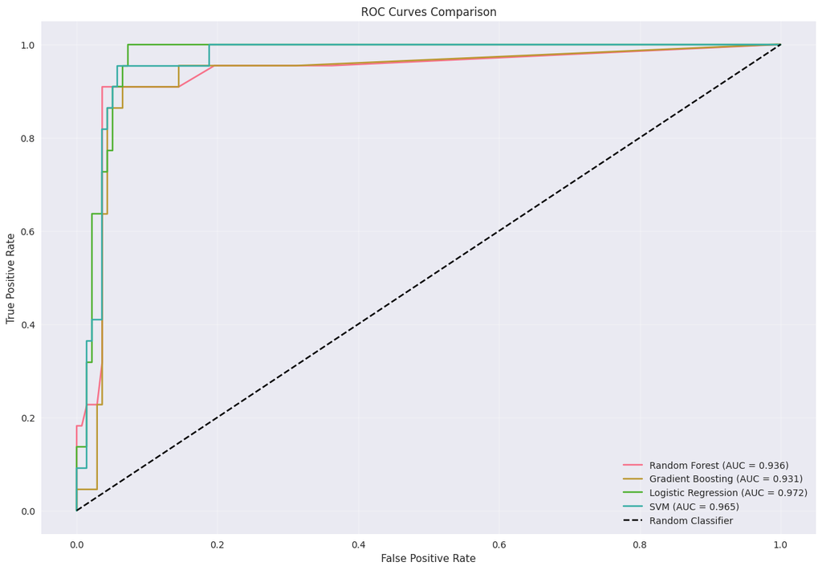

```python
# Visualize model performance
plt.figure(figsize=(15, 10))

# ROC Curves
for name, result in results.items():
    fpr, tpr, _ = roc_curve(y_test, result['y_pred_proba'])
    plt.plot(fpr, tpr, label=f"{name} (AUC = {result['auc_score']:.3f})")

plt.plot([0, 1], [0, 1], 'k--', label='Random Classifier')
plt.xlabel('False Positive Rate')
plt.ylabel('True Positive Rate')
plt.title('ROC Curves Comparison')
plt.legend()
plt.grid(True, alpha=0.3)
plt.show()
```

```python
from tabulate import tabulate
print(tabulate(df_model_comparison, headers='keys', tablefmt='grid'))
```

```
+----+---------------------+-------------+---------------+--------------+
|    | Model               |   AUC Score |   CV AUC Mean |   CV AUC Std |
+====+=====================+=============+===============+==============+
|  2 | Logistic Regression |    0.972003 |      0.982274 |    0.0164582 |
+----+---------------------+-------------+---------------+--------------+
|  3 | SVM                 |    0.964756 |      0.982913 |    0.0218447 |
+----+---------------------+-------------+---------------+--------------+
|  0 | Random Forest       |    0.93643  |      0.979731 |    0.0221619 |
+----+---------------------+-------------+---------------+--------------+
|  1 | Gradient Boosting   |    0.93083  |      0.952461 |    0.0543706 |
+----+---------------------+-------------+---------------+--------------+
```

From the graph and table above, we can see that, overall, the models perform similarly. However, logistic regression and SVM perform slightly better, with logistic regression achieving slightly better AUC scores than SVM.

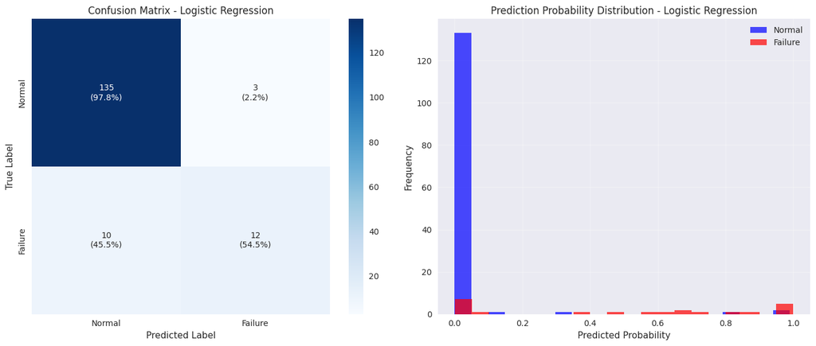

```python
plt.figure(figsize=(14, 6))
plt.subplot(1, 2, 1)
cm = confusion_matrix(y_test, results[best_model_name]['y_pred'])
cm_percent = cm.astype('float') / cm.sum(axis=1)[:, np.newaxis] * 100

annot = np.empty_like(cm).astype(str)
nrows, ncols = cm.shape
for i in range(nrows):
    for j in range(ncols):
        annot[i, j] = f"{cm[i, j]}\n({cm_percent[i, j]:.1f}%)"

sns.heatmap(cm, annot=annot, fmt='', cmap='Blues',
            xticklabels=['Normal', 'Failure'],
            yticklabels=['Normal', 'Failure'])
plt.title(f'Confusion Matrix - {best_model_name}')
plt.ylabel('True Label')
plt.xlabel('Predicted Label')

plt.subplot(1, 2, 2)
plt.hist(results[best_model_name]['y_pred_proba'][y_test == 0],
         alpha=0.7, label='Normal', bins=20, color='blue')
plt.hist(results[best_model_name]['y_pred_proba'][y_test == 1],
         alpha=0.7, label='Failure', bins=20, color='red')
plt.xlabel('Predicted Probability')
plt.ylabel('Frequency')
plt.title(f'Prediction Probability Distribution - {best_model_name}')
plt.legend()
plt.grid(True, alpha=0.3)

plt.tight_layout()
plt.show()
```

Above, we have the confusion matrix on the left, which helps us understand how the model is performing in terms of classification. In other words, almost 98% of the data that did not fail were correctly predicted. However, only 54.5% of the failure cases would be detected by this model. We need to understand whether the failure cases that were not detected are related to the 'unknown' cases we detected previously.

=========================================================

## 5. Analyze variable importance

In this step, we will only consider the best model obtained, which is Logistic Regression.

```python
df_importance = pd.DataFrame({
    'feature': df_features_enhanced.columns,
    'coefficient': np.abs(best_model.coef_[0])  # Using absolute values just to get the magnitude of the coefficients
}).sort_values('coefficient', ascending=False)
```

```python
df_importance.head()
```

|  | feature | coefficient |
| --- | --- | --- |
| 4 | VibrationX | 0.870623 |
| 33 | Temperature_mean_5 | 0.870296 |
| 13 | VibrationX_mean_3 | 0.834479 |
| 5 | VibrationY | 0.834360 |
| 1 | Preset_2 | 0.819876 |

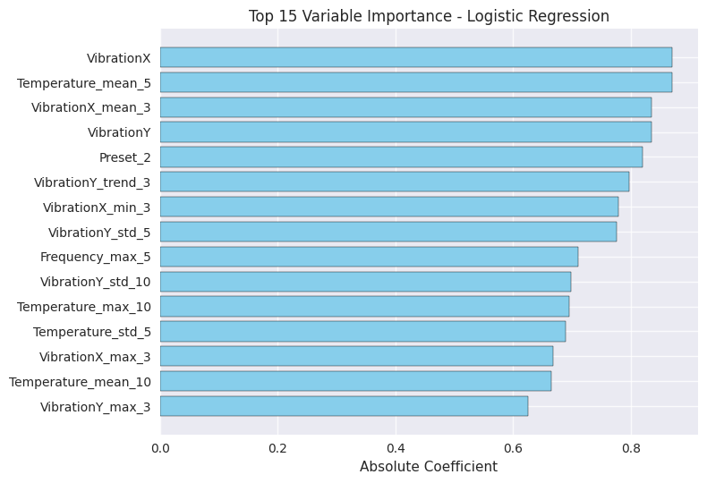

```python
top_features = df_importance.head(15).sort_values('coefficient', ascending=True)

plt.barh(top_features['feature'], top_features['coefficient'], color='skyblue', edgecolor='black')
plt.xlabel('Absolute Coefficient')

plt.title(f'Top 15 Variable Importance - {best_model_name}')
plt.grid(True, alpha=0.8)

plt.tight_layout()
plt.show()
```

From the graph above, we can see that the most important variable for the model's decision-making is VibrationX, followed by the average temperature in a window of 5 cycles.